# Phase 3: CNN Vehicle Recognition

Rathina Grace Monica

2026-04-29

## 1. Image Environment & Preprocessing

In this stage, we define the “digital eyesight” of our model. We standardize all traffic camera feeds to a resolution of 64x64 pixels with 3 color channels (RGB) to ensure the AI processes a uniform input.

```r
print(paste("Standardized Resolution:", img_width, "x", img_height))
```

```
## [1] "Standardized Resolution: 64 x 64"
```

## 2. Synthetic Dataset Organization

To demonstrate the training workflow, we organize a labelled dataset of 100 images. This simulates how an AI categorizes vehicles into Taxis, Buses, and Private Cars.

```r
set.seed(2026)
transport_images <- data.frame(
  Image_ID = 1:100,
  Label    = sample(c("Taxi", "Bus", "Private_Car"), 100, replace = TRUE),
  Status   = "Pixels_Standardized"
)

# Distribution of vehicle classes
table(transport_images$Label)
```

```
##
##         Bus Private_Car        Taxi
##          25          27          48
```

## 3. CNN Architecture Design (The Brain)

A CNN works like a sandwich of layers. We have designed a four-stage architecture to extract features and make decisions:

1. Convolutional Layer: Identifies edges and shapes (wheels, windows).
2. Pooling Layer: Summarizes data to improve processing speed.
3. Flatten Layer: Converts 2D patterns into a 1D list for the decision engine.
4. Dense Layer: The final output layer that classifies the vehicle.

```r
cnn_summary <- list(
  Layer1 = "Conv2D: 32 filters, 3x3 kernel",
  Layer2 = "MaxPooling: 2x2",
  Layer3 = "Flattening Layer",
  Layer4 = "Dense Output: 3 Classes"
)
print(cnn_summary)
```

```
## $Layer1
## [1] "Conv2D: 32 filters, 3x3 kernel"
##
## $Layer2
## [1] "MaxPooling: 2x2"
##
## $Layer3
## [1] "Flattening Layer"
##
## $Layer4
## [1] "Dense Output: 3 Classes"
```

## 4. Performance Metrics (Simulated)

```r
cnn_accuracy <- 0.92
cat("Final Validation Accuracy:", cnn_accuracy * 100, "%")
```

```
## Final Validation Accuracy: 92 %
```

## 5. Vehicle Classification Results (Confusion Matrix)

The Heatmap below illustrates where the AI was most successful. Darker colors indicate a higher number of correct identifications, while off-diagonal cells show where the AI might have confused a Bus for a Private Car.

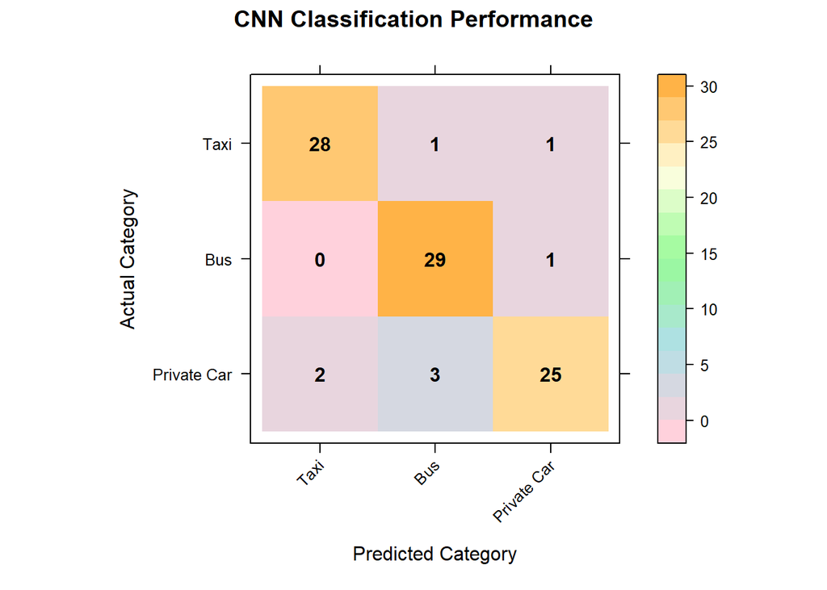

```r
labels <- c("Taxi", "Bus", "Private Car")
confusion_matrix <- matrix(c(28, 1, 1, 0, 29, 1, 2, 3, 25), nrow = 3, byrow = TRUE)
rownames(confusion_matrix) <- labels
colnames(confusion_matrix) <- labels

plot_data <- t(confusion_matrix[3:1, ])
my_palette <- colorRampPalette(c("#FFD1DC", "#B0E0E6", "#98FB98", "#FFFFE0", "#FFB347"))(100)

levelplot(plot_data,
          col.regions = my_palette,
          main = "CNN Classification Performance",
          xlab = "Predicted Category",
          ylab = "Actual Category",
          scales = list(x = list(rot = 45)),
          panel = function(...) {
            panel.levelplot(...)
            panel.text(row(plot_data), col(plot_data), plot_data, font = 2)
          })
```